# Analysis of Income and Market Value

- Show All Code
- Hide All Code
- View Source

Author

Eric, Visruth, Sebastian, Ryan

# 1 Introduction

In this project, we analyze the relationship between the daily income of individuals and the market value of listed companies (as a percentage of GDP) across various countries. The data for this analysis comes from two CSV files: `market_value_of_listed_companies_percent_of_gdp.csv` and `mincpcap_cppp.csv`.

## 1.1 Data and Variable Description

### 1.1.1 Data Sources

1. **Market Value of Listed Companies (% of GDP)**
   - This dataset provides information on the market value of all publicly traded companies in various countries, expressed as a percentage of the country’s GDP for multiple years. The market value of listed companies refers to the total value of a company’s shares of stock. It is calculated by multiplying the share price by the number of outstanding shares. This value represents the aggregate value of the companies’ equity on the stock market.
   - **Variables**
     - `country`: The name of the country.
     - `year`: The year for which the data was recorded.
     - `market_value`: The market value of listed companies as a percentage of GDP.
2. **Daily Income**
   - This dataset provides the average daily income per capita for various countries over multiple years, adjusted for purchasing power parity (PPP). PPP is an economic theory that compares different countries’ currencies through a basket of goods approach. It allows for more accurate comparisons of living standards and economic productivity between countries by accounting for differences in price levels.
   - **Variables**
     - `country`: The name of the country.
     - `year`: The year for which the data is recorded.
     - `income`: The average daily income per capita in constant PPP dollars.

### 1.1.2 Data Collection Methods

The data on the market value of listed companies and daily income per capita is collected by various international financial organizations and statistical agencies. These organizations compile data from national statistical offices, stock exchanges, and other financial institutions. The market value data is derived from stock market data, while the income data is adjusted for PPP to account for differences in cost of living across countries.

### 1.1.3 Hypothesized Relationship

We hypothesize that there is a positive relationship between a country’s average daily income per capita and the market value of its listed companies as a percentage of GDP. This hypothesis is based on the idea that higher individual incomes could correlate with higher levels of investment, corporate profits, and economic activity, leading to greater market value of listed companies.

```r
library(tidyverse)
library(broom)
library(gganimate)
library(gifski)
library(knitr)
library(kableExtra)
library(png)

set.seed(0)

market <- read_csv("market_value_of_listed_companies_percent_of_gdp.csv")
income <- read_csv("mincpcap_cppp.csv")
```

## 1.2 Data Cleaning Process

### 1.2.1 Importing and Reshaping Data

First, we import the data from the two CSV files. The data is initially in a wide format, where each year is represented as a separate column. To facilitate analysis, the data is reshaped into a long format, where each row represents a single country’s data for a specific year. This restructuring helps in merging the two datasets and for analysis.

### 1.2.2 Merging Datasets

Once the data is reshaped, we merge the two datasets based on the common columns, which are the country names and years.

### 1.2.3 Handling Missing Values

Any rows with missing values in either the market value or income columns are removed. This step is crucial as missing data can lead to biased results and affect the validity of the analysis.

### 1.2.4 Summary of Cleaned Data

The resulting dataset contains the following columns:

- `country`: The name of the country.
- `year`: The year for which the data is recorded.
- `market_value`: The market value of listed companies as a percentage of GDP.
- `income`: The average daily income per capita in constant PPP dollars.

```r
market <- market |>
  pivot_longer(cols = -country, names_to = "year", values_to = "market_value")

income <- income |>
  pivot_longer(cols = -country, names_to = "year", values_to = "income")

data <- market |>
  inner_join(income, by = c("country", "year")) |>
  drop_na() # removing years which don't have both market value and income data
```

By cleaning and merging the datasets, we have prepared a comprehensive dataset that allows us to explore the relationship between daily income and the market value of listed companies across different countries and years. The next steps involve performing statistical analyses and visualizations to test our hypothesis and uncover insights from the data.

# 2 Linear Regression

## 2.1 Data Visualization

### 2.1.1 Visualize the relationship between the quantitative variables

In order to understand the relationship between income and the market value (% of GDP), we will start by graphing a scatterplot of the two variables.

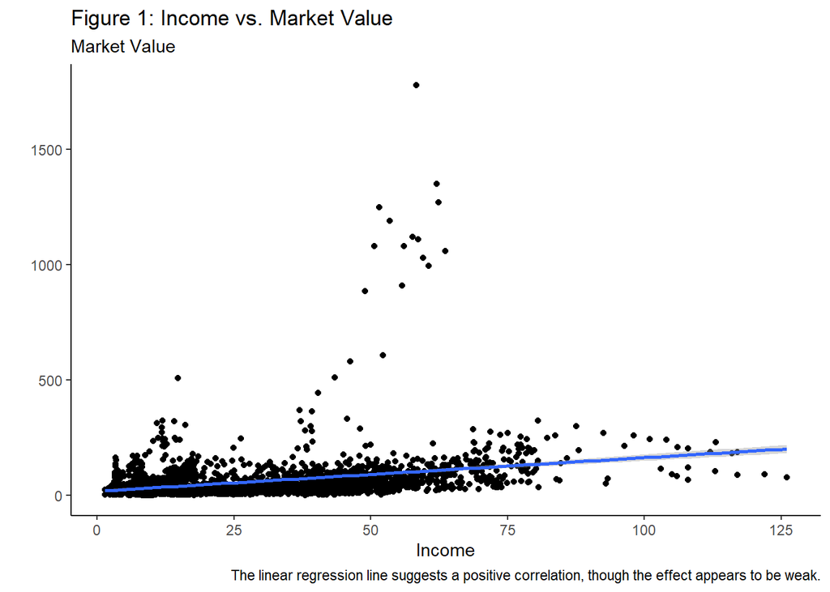

```r
data |>
  ggplot(aes(
    x = income,
    y = market_value
  )) +
  geom_jitter() +
  geom_smooth(method = "lm") +
  theme_classic() +
  labs(
    title = "Figure 1: Income vs. Market Value",
    y = "",
    subtitle = "Market Value",
    x = "Income",
     caption = "The linear regression line suggests a positive correlation, though the effect appears to be weak."
  )
```

Figure 1 above, shows that the majority of the data points are concentrated below the market value of 500, indicating that most observed market values are relatively low. There are a few data points with significantly higher market values, forming a sparse distribution above 500, which are identified as outliers.

It also includes a linear regression line with a positive slope, suggesting a slight positive correlation between Income and Market Value. As income increases, market value tends to increase linearly, though the effect is small.

### 2.1.2 Visualize the relationship between the quantitative variables

To further examine how these variables have evolved over time, we created an animated plot which shows how the relationship between income and the market value (% of GDP) of each country have changed each year.

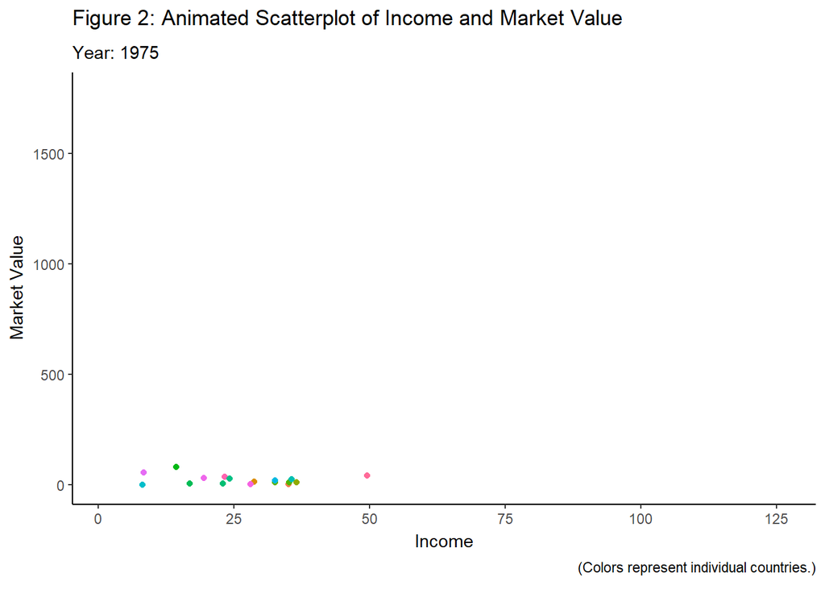

```r
data |>
  mutate(year = as.integer(year)) |>
  ggplot(aes(
    x = income,
    y = market_value,
    color = country
  )) +
  geom_jitter() +
  theme_classic() +
  labs(
    title = "Figure 2: Animated Scatterplot of Income and Market Value",
    y = "Market Value",
    x = "Income",
    caption = "(Colors represent individual countries.)" ) +
  theme(legend.position = "none") +
  transition_time(year) +
  labs(subtitle = "Year: {frame_time}")
```

The animated plot seen in Figure 2, significantly enhances the understanding of the linear relationship between the two variables. As the animation progresses, it becomes evident that as the income of countries increases over the years, there is a general trend of increasing market value (measured as a $ of GDP) for public companies. Furthermore, the color of each data point is mapped to specific countries, making it easier to track and follow the trajectories of individual countries.

This is particularly useful in identifying patterns and deviations from the overall trend. For instance, the outlier points identified in the initial static scatterplot are now shown to originate from the same country. This revelation provides context to the outliers, demonstrating that they are not indicative of the general relationship observed in most other countries.

## 2.2 Linear Regression Model (LRM)

In this section, we continue our analysis of the relationship between income and the market value (% of GDP) by employing a linear regression model.

### 2.2.1 What’s an LRM?

Linear regression is a statistical technique used to model the relationship between two variables: a dependent variable (in this case, the mean market value of listed companies as a percentage of GDP) and one or more independent variables (here, the mean income per capita). It assumes a linear relationship, meaning that a change in the independent variable is associated with a proportional change in the dependent variable.

However, before we can do this, we first must start by condensing our data to be more accurately represented by the regression model. We do this by finding the average income and market value of each country. Below is a scatterplot of the summarized data.

```r
data_means <- data |>
  group_by(country) |> # grouping by country
  summarize(
    mean_market_value = mean(market_value),
    sem_market_value = sd(market_value) / sqrt(n()),
    mean_income = mean(income),
    sem_income = sd(income) / sqrt(n()),
    .groups = "drop"
  )
```

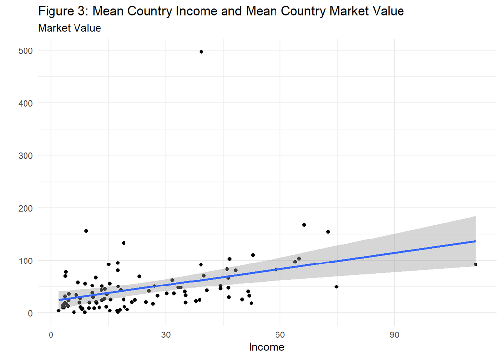

```r
data_means |>
  ggplot(aes(
    x = mean_income,
    y = mean_market_value
  )) +
  geom_jitter() +
  geom_smooth(method = "lm") +
  theme_minimal() +
  labs(
    title = "Figure 3: Mean Country Income and Mean Country Market Value",
    subtitle = "Market Value",
    y = "",
    x = "Income"
  )
```

The scatterplot in Figure 3 reveals a positive correlation between mean country income and mean country market value. This means that, on average, as a country’s income level increases, the average market value of its listed companies (measured as a percentage of GDP) also tends to increase. This trend is further confirmed by the blue regression line, which suggests a roughly linear relationship between the two variables.

Now that the data has been summarized, we move on to fitting the linear model to our data. The table below shows the relationship between the two variables and will be used to construct the estimated regression model.

```r
mv_lm <- lm(mean_market_value ~ mean_income, data = data_means)
mv_lm_summary <- broom::tidy(mv_lm)

knitr::kable(mv_lm_summary,
  col.names = gsub(
    "[.]",
    " ",
    c("Term", "Coefficient Estimate", "Standard Error", "T-Statistic", "P-Value")
  ),
  align = "ccccc",
  caption = "Table 1: Summary of Linear Regression Model Coefficients",
  digits = 3)
```

Table 1: Summary of Linear Regression Model Coefficients

| Term | Coefficient Estimate | Standard Error | T-Statistic | P-Value |
| --- | --- | --- | --- | --- |
| (Intercept) | 22.254 | 8.709 | 2.555 | 0.012 |
| mean_income | 1.025 | 0.271 | 3.783 | 0.000 |

In general, an estimated regression model can be represented as:

$$\text{Market Value (\% of GDP)} = \hat{\beta}_0 + \hat{\beta}_1 \times \text{Daily Income per Capita} + \epsilon$$

### 2.2.2 Interpretation of the coefficients:

This intercept (22.25) suggests that even with zero mean income per capita, the market value of listed companies would be estimated to be 22.25% of GDP. This interpretation should be taken with caution as it represents an extrapolation beyond the observed data.

## 2.3 Model Fit

```r
mv_lm_augmented <- augment(mv_lm)

# Calculate Variances
response_var <- var(mv_lm_augmented$.fitted +
  mv_lm_augmented$.resid)

fitted_var <- var(mv_lm_augmented$.fitted)

residual_var <- var(mv_lm_augmented$.resid)

# Create a DF for the Table
variance_table <- data.frame(
  Source = c(
    "Response Values",
    "Fitted Values",
    "Residuals"
  ),
  Variance = c(
    response_var,
    fitted_var,
    residual_var
  )
)

# Format with kableExtra
kableExtra::kable(
  variance_table,
  align = "cc",
  col.names = c(
    "Source of Variation",
    "Variance"
  ),
  digits = 3,
  caption = "Table 2: Variances from the Linear Regression Model",
  booktabs = TRUE
) |>
  kable_styling(latex_options = "striped", full_width = FALSE)
```

Table 2: Variances from the Linear Regression Model

| Source of Variation | Variance |
| --- | --- |
| Response Values | 3359.400 |
| Fitted Values | 435.808 |
| Residuals | 2923.592 |

```r
r_sq <- fitted_var / response_var

value_r_sq <- paste("R-squared:", round(r_sq, 3))

value_r_sq
```

```
[1] "R-squared: 0.13"
```

The R-squared value suggests that only approximately 13% of the variation in market value is explained by income. This implies that other factors not included in our model play a significant role in determining market value.

# 3 Simulation

## 3.1 Visualizing Simulations from the Model

### 3.1.1 Generating Predictions and Simulated Data

First, we used a simple linear regression model to generate predictions for the market value based on income. These predictions were then adjusted with random errors based on the residual standard error from the linear regression model to create simulated data. The resulting scatterplots, both for the observed and simulated data, were analyzed to understand the similarities and differences between them.

```r
# Generating Sim-ed Data
pred <- predict(mv_lm)
est_sigma <- sigma(mv_lm)
```

```r
# Adding Random Error
rand_error <- function(x, mean = 0, sd){
  x + rnorm(length(x), mean = mean, sd = sd)
}

sim_response <- tibble(sim_mv = rand_error(pred,
                                            sd = est_sigma))
```

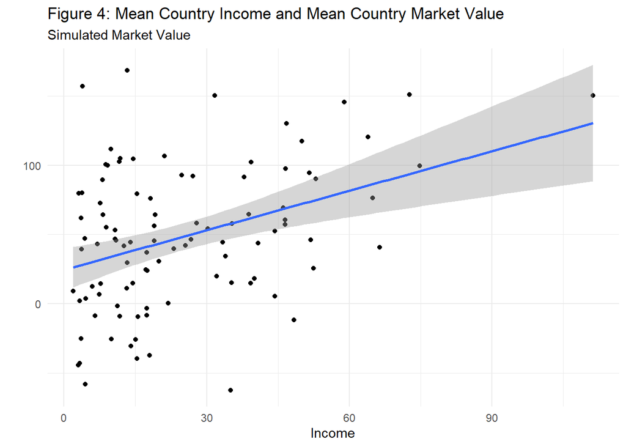

```r
# Generating market values and plotting
data_means |>
  bind_cols(sim_response) |>
  ggplot(aes(
    x = mean_income,
    y = sim_mv
  )) +
  geom_jitter() +
  geom_smooth(method = "lm") +
  theme_minimal() +
  labs(
    title = "Figure 4: Mean Country Income and Mean Country Market Value",
    subtitle = "Simulated Market Value",
    y = "",
    x = "Income"
  )
```

### 3.1.2 Comparing Simulated Data to Observed Data

Both figures 3 & 4 show a positive trend line, confirming our hypothesis that higher income correlates with higher market value. In both plots, a significant number of data points are below a market value of 100, indicating that most countries have market values within this range. Additionally, as both plots contain outliers, this suggests variability in market values that the model attempts to capture.

The observed data has a more skewed distribution with extreme outliers exceeding 500, while the simulated data points are more evenly spread around the regression line, displaying a more normal distribution. It also shows higher variability and greater spread in market values, indicating that factors other than income significantly influence market value. On the other hand, the simulated data shows a more constrained spread, emphasizing the model’s limitations in capturing the variability in market values.

The comparison underscores that while the linear regression model depicts the general positive trend between income and market value, it underestimates the variability observed in the real-world data. The outliers in the observed data suggests that additional factors beyond income play a role in determining the market value of listed companies.

## 3.2 Generating Multiple Predictive Checks

The purpose of generating simulated datasets is to provide a benchmark against which we can compare our observed data. By comparing the observed data to the distribution of simulated data, we can assess whether our model’s assumptions are reasonable and how well it captures the underlying data generating process.

```r
n_sims <- 1000
sim_data <- matrix(NA, nrow = nrow(data_means), ncol = n_sims)

for (i in 1:n_sims) {
  sim_data[, i] <- rand_error(pred, sd = est_sigma)
}

sim_data <- as.data.frame(sim_data)
names(sim_data) <- paste0("sim", 1:n_sims)
sim_data <- cbind(data_means, sim_data)
```

### 3.2.1 Comparing Against Regression

To assess how well our linear model captures the true relationship between mean income and market value, we conducted predictive checks. These checks involve generating numerous simulated datasets based on our model’s parameters and comparing them to our observed data. Each simulated dataset represents a plausible outcome if our model were a perfect representation of reality.

```r
# vector to store values
r_squared_values <- numeric(n_sims)
for (i in 1:n_sims) {

  sim_data_temp <- sim_data |>
    select(mean_income, starts_with("sim")) |>
    rename(simulated_mv = paste0("sim", i)) # Rename

  # Join
  sim_data_temp <- sim_data_temp |>
    inner_join(data_means|> select(mean_income, mean_market_value), by = "mean_income")

  # LRM
  sim_lm <- lm(mean_market_value ~ simulated_mv, data = sim_data_temp)

  # Store
  r_squared_values[i] <- summary(sim_lm)$r.squared
}
```

We regressed the observed market values against each of the 1,000 simulated datasets, calculating the R-squared value for each regression. The distribution of these R-squared values reveals the range of model fit we would expect to see if our model were accurate.

### 3.2.2 Plotting R-squared Distribution

Visualize distribution of the R-sq. values.

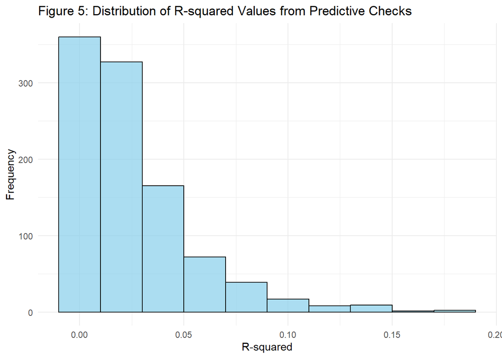

```r
# Create a histogram of the R-squared values
ggplot(data.frame(R_squared = r_squared_values),
       aes(x = R_squared)) +
  geom_histogram(binwidth = 0.02,
                 fill = "skyblue",
                 color = "black",
                 alpha = 0.7) +

  labs(title = "Figure 5: Distribution of R-squared Values from Predictive Checks",
       x = "R-squared",
       y = "Frequency") +
  theme_minimal()
```

**Considerations:**

- **Assumption of Correct Model:** The simulations are based on the assumption that the linear model is the correct model for the data. If the underlying relationship is different (e.g., non-linear), the predictive checks might not be reliable.
- **Data Limitations:** The quality of the simulations depends on the quality of the original data. If there are measurement errors or outliers in the original data, these will also affect the simulations.